# forecast_combine

## Overview

forecast_combine is a Python library built upon the foundation of the sktime library, designed to simplify and streamline the process of forecasting and prediction model aggregation. It provides tools for aggregating predictions from multiple models, evaluating their performance, and visualizing the results. Whether you're working on time series forecasting, data analysis, or any other predictive modeling task, forecast_combine offers a convenient and efficient way to handle aggregation and comparison.

## Key Features

- **Model Aggregation:** Easily aggregate predictions from multiple models using various aggregation modes such as best model overall, best model per horizon, inverse score weighted average model, and more.
- **Out-of-Sample Evaluation:** Evaluate model performance using out-of-sample data and choose the best models based on user-defined performance metrics.
- **Visualization:** Visualize model performance, aggregated predictions, and prediction intervals with built-in plotting functions.
- **Flexibility:** Accommodate various aggregation strategies, forecast horizons, and performance metrics to cater to your specific use case.

## Installation

```bash
pip install forecast_combine
```

## Usage

```python
# Read the data
data = pd.Series(np.cumsum(np.random.normal(0, 1, size=1000)),
                 index=pd.date_range(end='31/12/2022', periods=1000)
                ).rename('y').to_frame()

# Import the package
from forecast_combine.model_select import ForecastModelSelect

# Import the packages of the models to test
from sktime.forecasting.naive import NaiveForecaster
from sktime.forecasting.statsforecast import (
    StatsForecastAutoARIMA,
    StatsForecastAutoETS,
    StatsForecastAutoTheta
)
from sktime.forecasting.tbats import TBATS
from sktime.forecasting.fbprophet import Prophet

ForecastingModels = {
    "Naive": NaiveForecaster(),
    "AutoARIMA": StatsForecastAutoARIMA(),
    "AutoETS": StatsForecastAutoETS(),
    "AutoTheta": StatsForecastAutoTheta(),
    "TBATS": TBATS(),
    "Prophet": Prophet()
}

model = ForecastModelSelect(
            data= data,
            depvar_str = 'y',
            exog_l=None,
            fh = 10,
            pct_initial_window=0.75,
            step_length = 25,
            models_d = ForecastingModels,
            freq = 'B',
            mode = 'nbest_average_horizon',
            score = 'RMSE',
            nbest = 2)

# compare models
model.select_best(score = 'MAPE')
# Visualize model comparison
model.plot_model_compare(score='MAPE', view='horizon')
model.plot_model_compare(score='MAPE', view='cutoff')

# Generate prediction
y_pred, y_pred_ints, preds, pred_ints =  model.predict(score='RMSE', ret_underlying=True)

# Visualize prediction
model.plot_prediction(y_pred = y_pred,
                     models_preds = preds,
                     y_pred_interval = y_pred_ints,
                     title = 'Prediction')
```

## Documentation

For detailed information about available classes, methods, and parameters, please refer to the [Documentation](https://amineraboun.github.io/forecast/).

## License

This project is licensed under the MIT License.

## Contributing

We welcome contributions from the community! If you have suggestions, bug reports, or feature requests, please open an issue or submit a pull request.

## Contact

For queries, support, or general inquiries, please feel free to reach me at amineraboun@gmail.com.

## Example 1: Single Model Forecast

# One Single Model Prediction

## Section 1: Data Preparation

### Import packages

```python
import pandas as pd
import numpy as np
import os
```

```python
# models necessary to define the forecasting models
from sktime.forecasting.statsforecast import StatsForecastAutoARIMA
from forecast_combine.forecast import Forecast
```

```python
from warnings import simplefilter
simplefilter('ignore')
```

### Lire les donnees

```python
data = pd.Series(np.cumsum(np.random.normal(0, 1, size=1000)),
                 index=pd.date_range(end='31/12/2022', periods=1000)).rename('y').to_frame()
data.head(2)
```

|  | y |
| --- | --- |
| 2020-04-06 | 0.873882 |
| 2020-04-07 | 0.847867 |

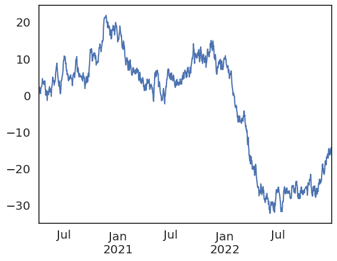

```python
data.y.plot()
```

## Section 2: Model Definition

```python
model = StatsForecastAutoARIMA(n_jobs = 4, trend=True, seasonal=True, max_p= 10, max_q=10)
```

```python
LF = Forecast(data = data,
                          depvar_str='y',
                          exog_l= None,
                          forecaster_name = 'AutoARIMA',
                          forecaster= model,
                          fh = 5,
                          pct_initial_window = 0.5,
                          step_length = 25,
                          freq = 'B')
```

## Section 3: In-sample vs Out-Of-smaple

### Cross validation Procedure

```
(<Figure size 1500x600 with 1 Axes>,
 <Axes: title={'center': 'Insample vs Out-Of-Sample'}, ylabel='y'>)
```

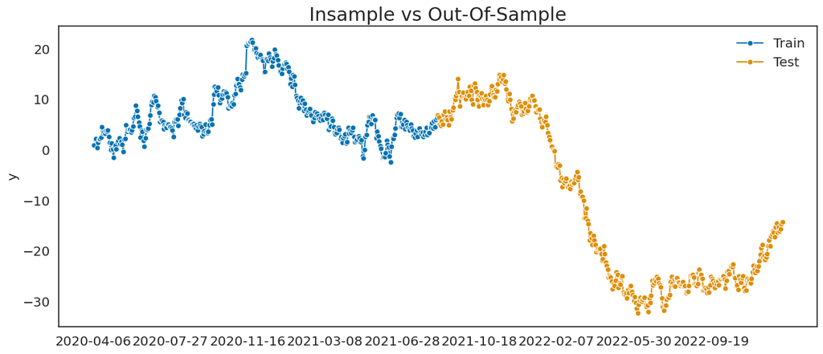

```python
LF.plot.plot_train_test(
    labels = ['Train', 'Test'],
    title='Insample vs Out-Of-Sample')
```

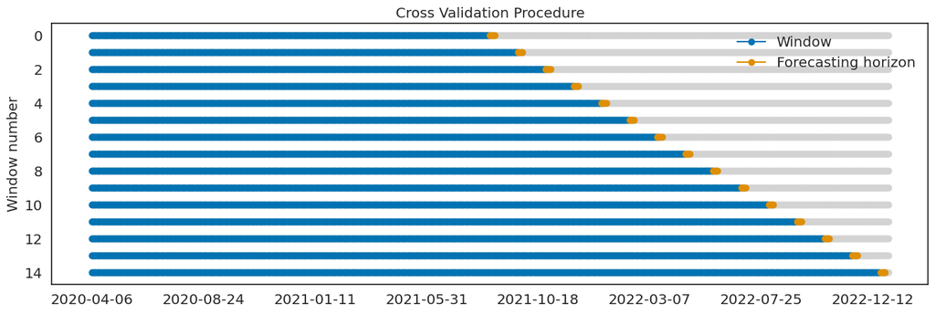

```python
LF.plot.plot_cv_procedure(xlabel='')
```

### Fit

```python
lf_fit= LF.fit(on='train')
```

### In Sample Evaluation

```python
pred = lf_fit.insample_predictions(nsample =200)
display(pred.head())
```

```
200it [00:02, 80.82it/s]
```

|  | index | y_pred | y_true | Abs_diff | horizon | cutoff |
| --- | --- | --- | --- | --- | --- | --- |
| 0 | 2020-04-09 | 2.012433 | 2.176069 | 0.163635 | 1 | 2020-04-08 |
| 1 | 2020-04-10 | 2.176069 | 0.382021 | 1.794048 | 2 | 2020-04-08 |
| 2 | 2020-04-13 | 0.382021 | 1.380491 | 0.998470 | 3 | 2020-04-08 |
| 3 | 2020-04-14 | 1.380491 | 2.049224 | 0.668734 | 4 | 2020-04-08 |
| 4 | 2020-04-15 | 2.049224 | 2.225920 | 0.176696 | 5 | 2020-04-08 |

```python
insample_perf_summary = lf_fit.insample_perf()
```

```python
insample_perf_summary['horizon']
```

| horizon | RMSE | MAPE |
| --- | --- | --- |
| 1 | 1.138705 | 0.678235 |
| 2 | 1.166277 | 0.521096 |
| 3 | 1.182358 | 0.496988 |
| 4 | 1.257838 | 0.631656 |
| 5 | 1.103625 | 0.705834 |

```python
display(insample_perf_summary['cutoff'].head())
display(insample_perf_summary['horizon'].head())
```

| cutoff | RMSE | MAPE |
| --- | --- | --- |
| 2020-04-08 | 0.971674 | 1.180078 |
| 2020-04-10 | 1.073250 | 0.334370 |
| 2020-04-13 | 1.119292 | 0.264788 |
| 2020-04-15 | 1.086897 | 0.213093 |
| 2020-04-16 | 1.114856 | 0.227686 |

| horizon | RMSE | MAPE |
| --- | --- | --- |
| 1 | 1.138705 | 0.678235 |
| 2 | 1.166277 | 0.521096 |
| 3 | 1.182358 | 0.496988 |
| 4 | 1.257838 | 0.631656 |
| 5 | 1.103625 | 0.705834 |

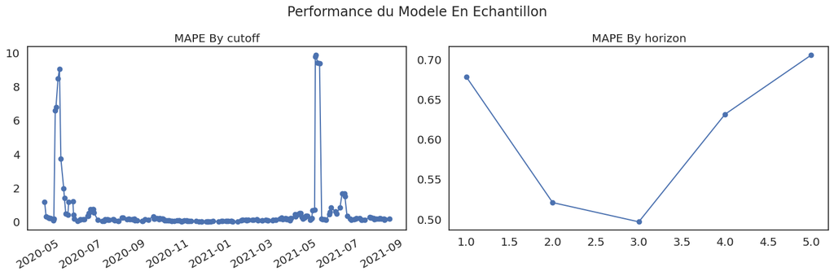

```python
lf_fit.plot.plot_insample_performance(metric='MAPE', title = 'Performance du Modele En Echantillon')
```

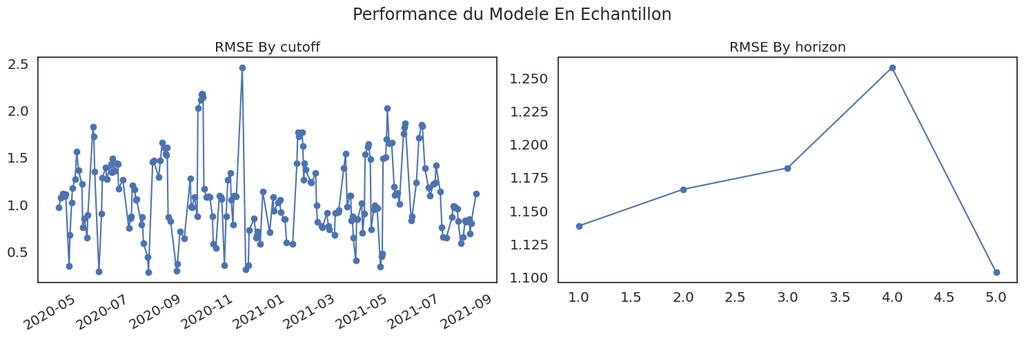

```python
lf_fit.plot.plot_insample_performance(metric='RMSE', title = 'Performance du Modele En Echantillon')
```

### Out-Of-sample Evaluation

```python
lf_eval= LF.evaluate()
```

```
Start forecaster AutoARIMA evalution....
 Depending on the forecaster this step may take couple of minutes. Please don't kill the kernel
Evaluation time: 0.08 minutes
```

```python
lf_eval.summary_results()
```

|  | Number of Folds | Avg Fit time (s) | Avg_pred_time (s) | Smallest training window | Largest training window | First cutoff | Last cutoff | Avg MAPE | Avg RMSE |
| --- | --- | --- | --- | --- | --- | --- | --- | --- | --- |
| 0 | 15 | 0.225217 | 0.081964 | 357 | 707 | 2021-08-17 | 2022-12-20 | 0.133514 | 1.702778 |

```python
lf_eval.summary_horizon()
```

| horizon | RMSE | MAPE |
| --- | --- | --- |
| 1 | 1.054197 | 0.060916 |
| 2 | 1.480390 | 0.086931 |
| 3 | 2.401521 | 0.193663 |
| 4 | 2.349567 | 0.180742 |
| 5 | 2.046415 | 0.145317 |

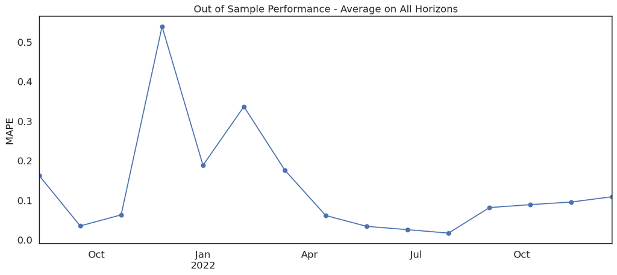

```python
lf_eval.plot.plot_oos_score(score = 'MAPE')
```

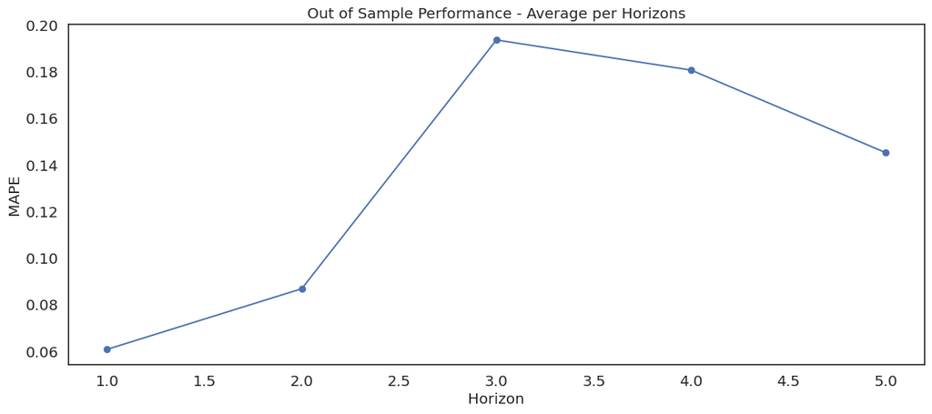

```python
lf_eval.plot.plot_oos_horizon(score = 'MAPE', xlabel = 'Horizon')
```

## Section 4: Generate predictions

```python
# First Fit on all the sample
LF.fit(on ='all')
# Predict
y_pred, y_pred_ints = LF.predict()
```

```
(<Figure size 1300x500 with 1 Axes>,
 <Axes: title={'center': 'ARIMA Prediction'}, ylabel='y'>)
```

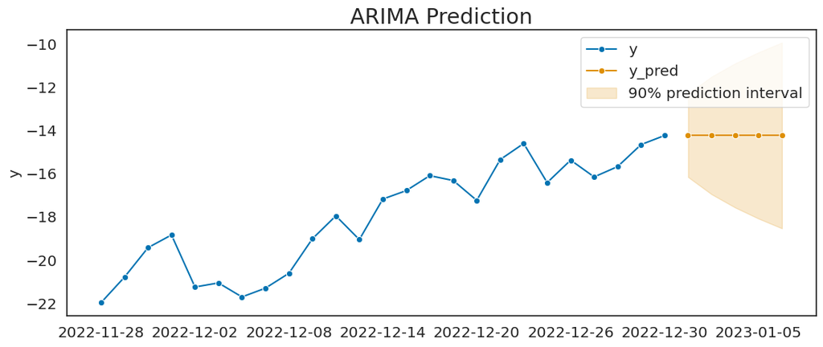

```python
LF.plot.plot_prediction(y_pred, y_pred_ints,
                        labels=['y', 'y_pred'],
                        title = 'ARIMA Prediction',
                        figsize = (13,5))
```

### Section 5: Update Predictions when new data comes in

```python
# create a dataframe with the new data
newdata = pd.concat([data,
                     pd.DataFrame(index=[y_pred.index[0]], columns =data.columns)
                    ])
newdata.loc[y_pred.index[0], 'BMC'] = y_pred.iloc[0]
newdata = newdata.ffill()
newdata.tail()
```

|  | y | BMC |
| --- | --- | --- |
| 2022-12-28 | -15.688168 | NaN |
| 2022-12-29 | -14.668027 | NaN |
| 2022-12-30 | -14.480525 | NaN |
| 2022-12-31 | -14.248787 | NaN |
| 2023-01-02 | -14.248787 | -14.248787 |

### Either with or without refitting the model

```
(<Figure size 1500x600 with 1 Axes>,
 <Axes: title={'center': 'Prediction'}, ylabel='y'>)
```

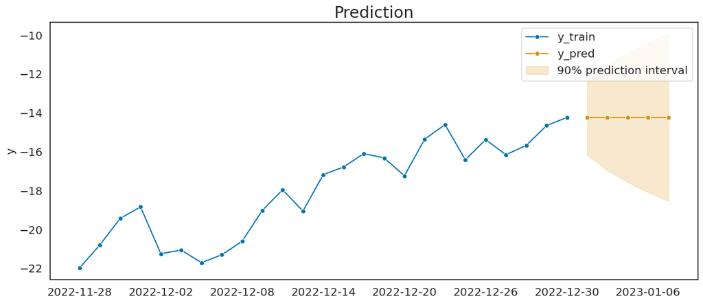

```python
y_pred, y_pred_ints = LF.update(newdata = newdata, refit=False)
LF.plot.plot_prediction(y_pred, y_pred_ints)
```

## Example 2: Combination of Several Models

# Compare Several Models

## Import packages

```python
import pandas as pd
import numpy as np

from warnings import simplefilter
simplefilter('ignore')
```

## Data Preparation

```python
data = pd.Series(np.cumsum(np.random.normal(0, 1, size=1000)),
                 index=pd.date_range(end='31/12/2022', periods=1000)).rename('y').to_frame()
data.head(2)
```

|  | y |
| --- | --- |
| 2020-04-06 | -0.253177 |
| 2020-04-07 | -1.825006 |

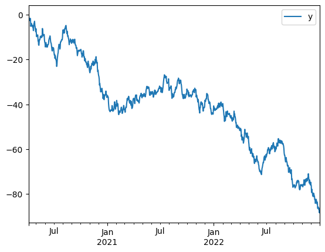

```python
data.plot()
```

## Section1: Difinir la liste des modeles a comparer

### Option 1 : List of Models from a LiquidityForecast Object List

Default choice if you have already estimated models and wish to compare them without re-estimating.

```
import pickle
LF_list= []
for f in ['forecaster1.pkl', 'forecaster2.pkl', 'forecaster3.pkl']:
    with open(f, 'rb') as file:
        LF_list.append(pickle.load(file))

model = lfs.LiquidityForecastModelSelect(LF_list= LF_list)
```

### Option 2: List of Models from a dictionary

Default choice if you want to reestimate the models

```python
# models necessary to define the forecasting models
from sktime.forecasting.naive import NaiveForecaster
from sktime.forecasting.statsforecast import (
    StatsForecastAutoARIMA,
    StatsForecastAutoETS,
    StatsForecastAutoTheta
)
from sktime.forecasting.tbats import TBATS
from sktime.forecasting.fbprophet import Prophet
```

```python
ForecastingModels = {
    "Naive": NaiveForecaster(),
    "AutoARIMA": StatsForecastAutoARIMA(),
    "AutoETS": StatsForecastAutoETS(),
    "AutoTheta": StatsForecastAutoTheta(),
    "TBATS": TBATS(),
    "Prophet": Prophet(),
}
```

```python
from forecast_combine.model_select import ForecastModelSelect
model = ForecastModelSelect(
            data= data,
            depvar_str = 'y',
            exog_l=None,
            fh = 10,
            pct_initial_window=0.75,
            step_length = 25,
            models_d = ForecastingModels,
            freq = 'B',
            mode = 'nbest_average_horizon',
            score = 'RMSE',
            nbest = 2)
```

## Section 2: Evaluate the model OOS

```python
summary_horizon, summary_results = model.evaluate()
```

```
Start forecaster Naive evalution....
 Depending on the forecaster this step may take couple of minutes. Please don't kill the kernel
Evaluation time: 0.006 minutes

Start forecaster AutoARIMA evalution....
 Depending on the forecaster this step may take couple of minutes. Please don't kill the kernel
Evaluation time: 0.257 minutes

Start forecaster AutoETS evalution....
 Depending on the forecaster this step may take couple of minutes. Please don't kill the kernel
Evaluation time: 0.359 minutes

Start forecaster AutoTheta evalution....
 Depending on the forecaster this step may take couple of minutes. Please don't kill the kernel
Evaluation time: 0.219 minutes

Start forecaster TBATS evalution....
 Depending on the forecaster this step may take couple of minutes. Please don't kill the kernel
```

```
14:39:56 - cmdstanpy - INFO - Chain [1] start processing
14:39:56 - cmdstanpy - INFO - Chain [1] done processing
```

```
Evaluation time: 0.843 minutes

Start forecaster Prophet evalution....
 Depending on the forecaster this step may take couple of minutes. Please don't kill the kernel
```

[output not shown]

```
Evaluation time: 0.029 minutes
```

```python
summary_horizon
```

| horizon | Naive RMSE | Naive MAPE | AutoARIMA RMSE | AutoARIMA MAPE | AutoETS RMSE | AutoETS MAPE | AutoTheta RMSE | AutoTheta MAPE | TBATS RMSE | TBATS MAPE | Prophet RMSE | Prophet MAPE |
| --- | --- | --- | --- | --- | --- | --- | --- | --- | --- | --- | --- | --- |
| 1 | 0.986270 | 0.012504 | 1.053019 | 0.013193 | 1.020297 | 0.012905 | 1.039470 | 0.013076 | 1.030824 | 0.013209 | 4.223247 | 0.053623 |
| 2 | 1.073971 | 0.012754 | 1.167492 | 0.014004 | 1.071367 | 0.013560 | 1.153430 | 0.013901 | 1.181646 | 0.014718 | 4.497611 | 0.061969 |
| 3 | 1.862403 | 0.026211 | 1.827001 | 0.024915 | 1.744147 | 0.024211 | 1.842973 | 0.025251 | 1.884706 | 0.026838 | 5.085417 | 0.071978 |
| 4 | 2.484381 | 0.034375 | 2.220268 | 0.031840 | 2.217785 | 0.030906 | 2.289233 | 0.032645 | 2.356428 | 0.033855 | 5.020506 | 0.074085 |
| 5 | 3.089062 | 0.040572 | 2.775343 | 0.037459 | 2.793197 | 0.036255 | 2.862206 | 0.038442 | 2.990550 | 0.039895 | 5.309852 | 0.077848 |
| 6 | 3.591063 | 0.046282 | 3.130722 | 0.041797 | 3.233892 | 0.041134 | 3.253064 | 0.042955 | 3.402862 | 0.044667 | 5.643671 | 0.081258 |
| 7 | 3.761184 | 0.049785 | 3.394800 | 0.045548 | 3.443876 | 0.043745 | 3.500837 | 0.046877 | 3.711270 | 0.048859 | 6.464898 | 0.090632 |
| 8 | 3.500638 | 0.046821 | 2.998948 | 0.041931 | 3.055749 | 0.039949 | 3.130550 | 0.043457 | 3.383524 | 0.045743 | 5.981629 | 0.083201 |
| 9 | 4.827942 | 0.063912 | 4.303898 | 0.058671 | 4.366969 | 0.056272 | 4.441960 | 0.060322 | 4.753453 | 0.062796 | 6.923088 | 0.092470 |
| 10 | 4.919671 | 0.061911 | 4.233568 | 0.056042 | 4.331756 | 0.053493 | 4.401511 | 0.057886 | 4.714734 | 0.060663 | 6.548794 | 0.088554 |

```python
summary_results
```

|  | Naive | AutoARIMA | AutoETS | AutoTheta | TBATS | Prophet |
| --- | --- | --- | --- | --- | --- | --- |
| Number of Folds | 7 | 7 | 7 | 7 | 7 | 7 |
| Avg Fit time (s) | 0.002078 | 2.022322 | 2.985928 | 1.823773 | 7.204911 | 0.179282 |
| Avg_pred_time (s) | 0.033324 | 0.170823 | 0.074318 | 0.041945 | 0.006198 | 0.05514 |
| Smallest training window | 536 | 536 | 536 | 536 | 536 | 536 |
| Largest training window | 686 | 686 | 686 | 686 | 686 | 686 |
| First cutoff | 2022-04-25 00:00:00 | 2022-04-25 00:00:00 | 2022-04-25 00:00:00 | 2022-04-25 00:00:00 | 2022-04-25 00:00:00 | 2022-04-25 00:00:00 |
| Last cutoff | 2022-11-21 00:00:00 | 2022-11-21 00:00:00 | 2022-11-21 00:00:00 | 2022-11-21 00:00:00 | 2022-11-21 00:00:00 | 2022-11-21 00:00:00 |
| Avg MAPE | 0.039513 | 0.03654 | 0.035243 | 0.037481 | 0.039124 | 0.077562 |
| Avg RMSE | 3.068123 | 2.786668 | 2.719274 | 2.866172 | 2.989013 | 5.191834 |

## Section 3: Select the best model

```python
model.select_best(score = 'MAPE')
```

| horizon | 1 | 2 | 3 | 4 | 5 | 6 | 7 | 8 | 9 | 10 |
| --- | --- | --- | --- | --- | --- | --- | --- | --- | --- | --- |
| Best_1 | Naive | Naive | AutoETS | AutoETS | AutoETS | AutoETS | AutoETS | AutoETS | AutoETS | AutoETS |
| Best_2 | AutoETS | AutoETS | AutoARIMA | AutoARIMA | AutoARIMA | AutoARIMA | AutoARIMA | AutoARIMA | AutoARIMA | AutoARIMA |
| Best_3 | AutoTheta | AutoTheta | AutoTheta | AutoTheta | AutoTheta | AutoTheta | AutoTheta | AutoTheta | AutoTheta | AutoTheta |
| Best_4 | AutoARIMA | AutoARIMA | Naive | TBATS | TBATS | TBATS | TBATS | TBATS | TBATS | TBATS |
| Best_5 | TBATS | TBATS | TBATS | Naive | Naive | Naive | Naive | Naive | Naive | Naive |
| Best_6 | Prophet | Prophet | Prophet | Prophet | Prophet | Prophet | Prophet | Prophet | Prophet | Prophet |

```python
model.avg_oos_horizon['MAPE']
```

| horizon | Naive | AutoARIMA | AutoETS | AutoTheta | TBATS | Prophet | Model Avg (all models) | Best 2 Model (over all) | Best 2 Model (per horizon) |
| --- | --- | --- | --- | --- | --- | --- | --- | --- | --- |
| 1 | 0.012504 | 0.013193 | 0.012905 | 0.013076 | 0.013209 | 0.053623 | 0.019752 | 0.013049 | 0.012704 |
| 2 | 0.012754 | 0.014004 | 0.013560 | 0.013901 | 0.014718 | 0.061969 | 0.021818 | 0.013782 | 0.013157 |
| 3 | 0.026211 | 0.024915 | 0.024211 | 0.025251 | 0.026838 | 0.071978 | 0.033234 | 0.024563 | 0.024563 |
| 4 | 0.034375 | 0.031840 | 0.030906 | 0.032645 | 0.033855 | 0.074085 | 0.039618 | 0.031373 | 0.031373 |
| 5 | 0.040572 | 0.037459 | 0.036255 | 0.038442 | 0.039895 | 0.077848 | 0.045078 | 0.036857 | 0.036857 |
| 6 | 0.046282 | 0.041797 | 0.041134 | 0.042955 | 0.044667 | 0.081258 | 0.049682 | 0.041465 | 0.041465 |
| 7 | 0.049785 | 0.045548 | 0.043745 | 0.046877 | 0.048859 | 0.090632 | 0.054241 | 0.044646 | 0.044646 |
| 8 | 0.046821 | 0.041931 | 0.039949 | 0.043457 | 0.045743 | 0.083201 | 0.050184 | 0.040940 | 0.040940 |
| 9 | 0.063912 | 0.058671 | 0.056272 | 0.060322 | 0.062796 | 0.092470 | 0.065740 | 0.057471 | 0.057471 |
| 10 | 0.061911 | 0.056042 | 0.053493 | 0.057886 | 0.060663 | 0.088554 | 0.063091 | 0.054767 | 0.054767 |

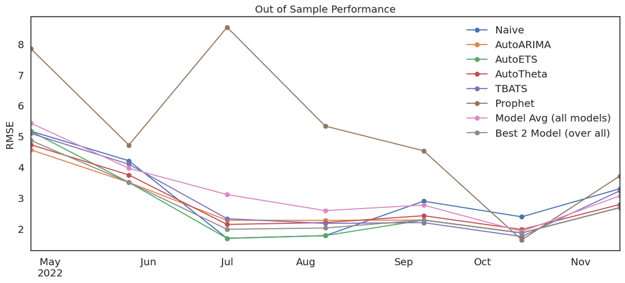

```python
model.plot_model_compare(
    score ='RMSE',
    view = 'cutoff',
    xlabel = '')
```

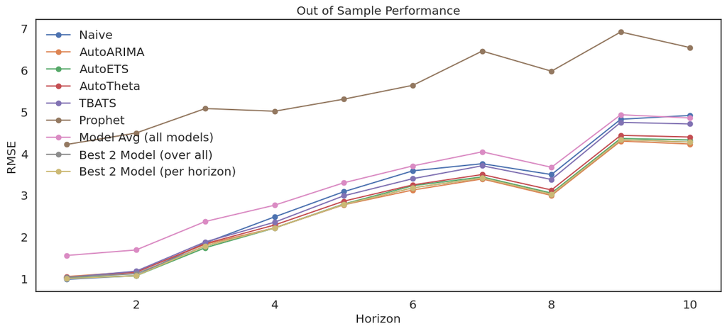

```python
model.plot_model_compare(
    score ='RMSE',
    view = 'horizon',
    xlabel = 'Horizon')
```

## Section 4 : Generate Predictions

The prediction aggregate the single models predictions is several ways:

- 'best': The prediction is based on the best model.
- 'best_horizon': The prediction is based on the best model for each horizon.
- 'average': The average of the prediction of all models.
- 'inverse_score': The weighted average prediction, where weights are inversely proportional to the model performance score.
- 'nbest_average': Average of the n best models. The n is given by the parameter nbest.
- 'nbest_average_horizon': Average of the n best models for each horizon. The n is given by the parameter nbest.

```
Model not fitted yet, or fitted on training sample alone
Fitting the model on the whole sample ...

Model not fitted yet, or fitted on training sample alone
Fitting the model on the whole sample ...

Model not fitted yet, or fitted on training sample alone
Fitting the model on the whole sample ...

Model not fitted yet, or fitted on training sample alone
Fitting the model on the whole sample ...

Model not fitted yet, or fitted on training sample alone
Fitting the model on the whole sample ...
```

```
14:40:15 - cmdstanpy - INFO - Chain [1] start processing
14:40:15 - cmdstanpy - INFO - Chain [1] done processing
```

```
Model not fitted yet, or fitted on training sample alone
Fitting the model on the whole sample ...
```

```
(<Figure size 1500x600 with 1 Axes>, <Axes: title={'center': 'Prediction'}>)
```

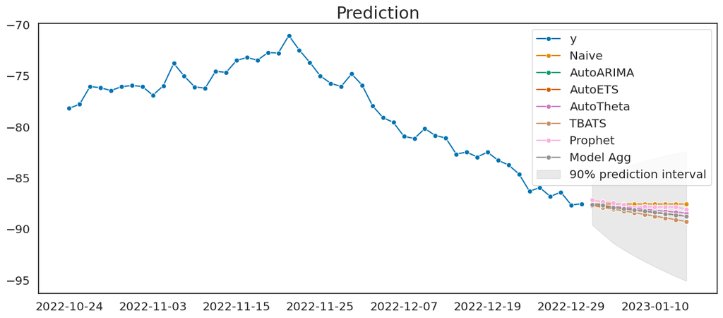

```python
y_pred, y_pred_ints, preds, pred_ints = model.predict(ret_underlying=True)
model.plot_prediction(y_pred = y_pred,
                     models_preds = preds,
                     y_pred_interval = y_pred_ints)
```

```
(<Figure size 1500x600 with 1 Axes>, <Axes: title={'center': 'Prediction'}>)
```

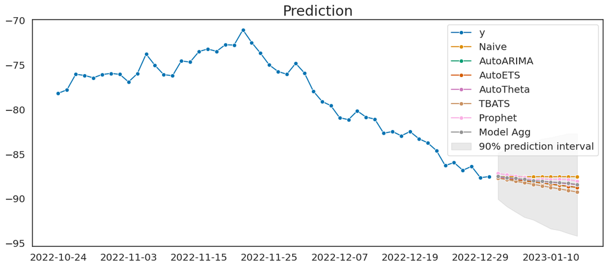

```python
y_pred, y_pred_ints, preds, pred_ints = model.predict(mode='inverse_score', ret_underlying=True)
model.plot_prediction(y_pred = y_pred,
                     models_preds = preds,
                     y_pred_interval = y_pred_ints)
```

## Section 5: Update data and regenerate the model

```python
# create a dataframe with the new data
newdata = pd.concat([data,
                     pd.DataFrame(index=[y_pred.index[0]], columns =data.columns)
                    ])
newdata.loc[y_pred.index[0], 'BMC'] = y_pred.iloc[0]
newdata = newdata.ffill()
```

```
(<Figure size 1500x600 with 1 Axes>, <Axes: title={'center': 'Prediction'}>)
```

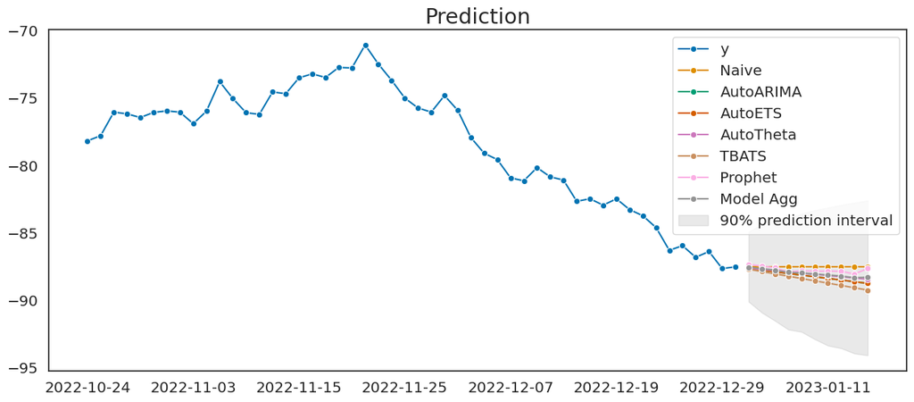

```python
y_pred, y_pred_ints, preds, pred_ints = model.update(newdata=newdata, mode='inverse_score', ret_underlying=True)
model.plot_prediction(y_pred = y_pred,
                     models_preds = preds,
                     y_pred_interval = y_pred_ints)
```